# NeRV and JSE

## Results: JSE

We’re using the same ordering of results as for NeRV: top left image is the the setting closest to the pure “reverse” KL divergence and the bottom right image is the ASNE result. Going from left to right and then top to bottom, more of the forward KL divergence is added to the cost function, which for JSE is indicated by the value of `kappa` decreasing.

### iris

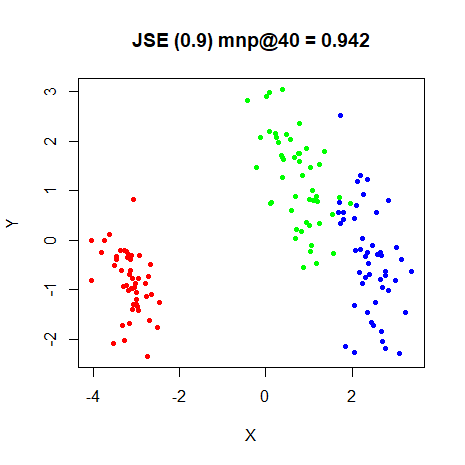

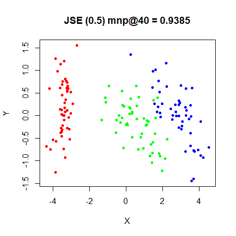

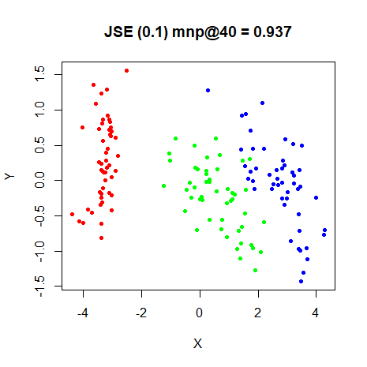

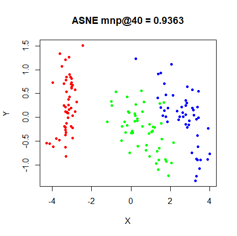

### s1k

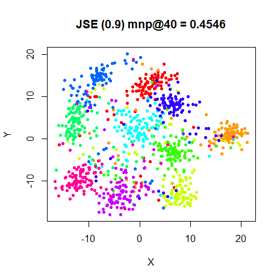

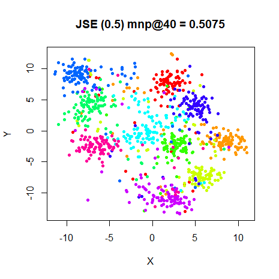

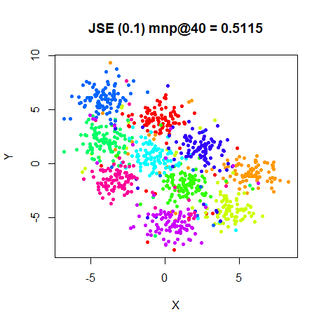

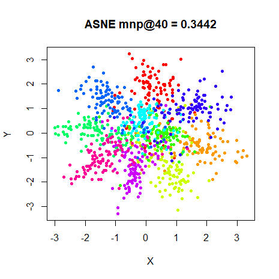

### oli

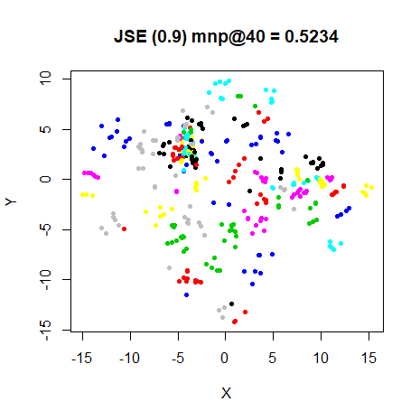

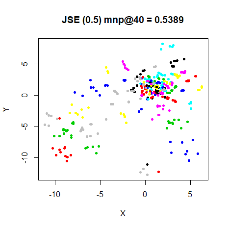

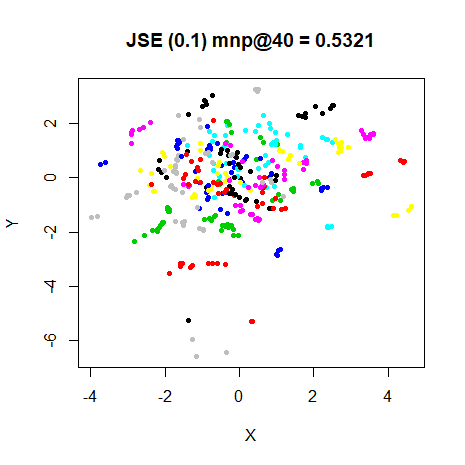

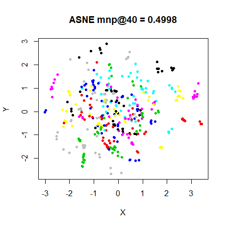

### frey

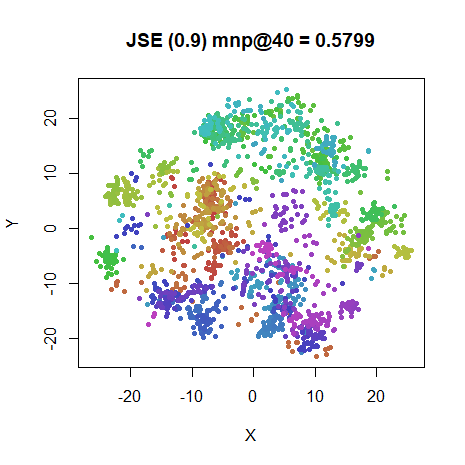

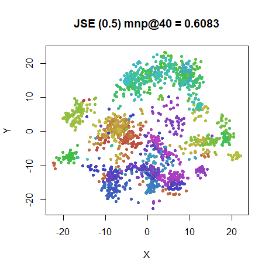

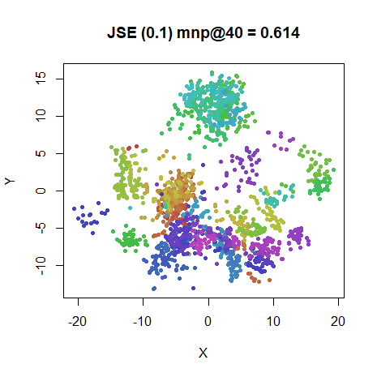

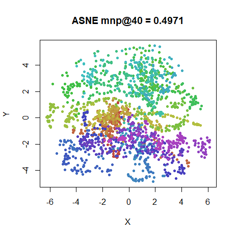

### coil20

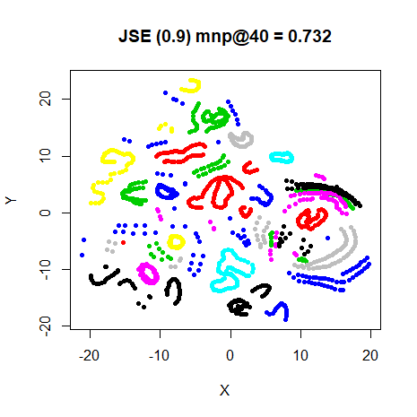

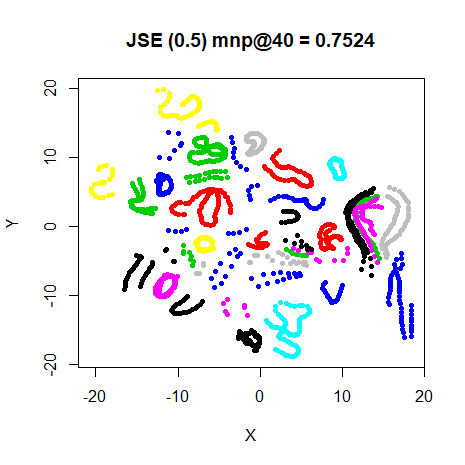

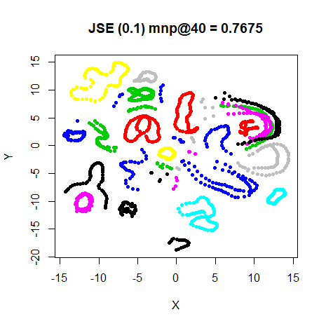

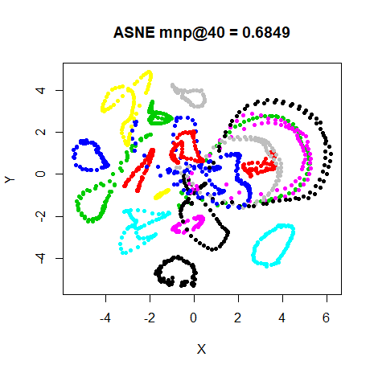

### mnist

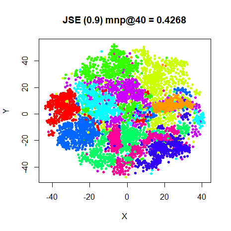

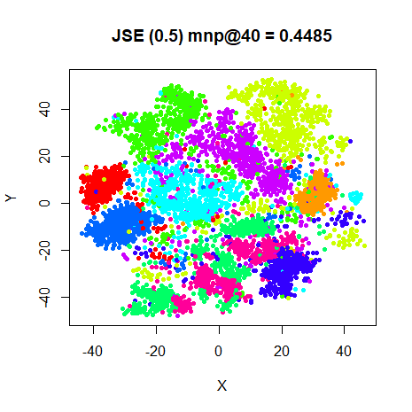

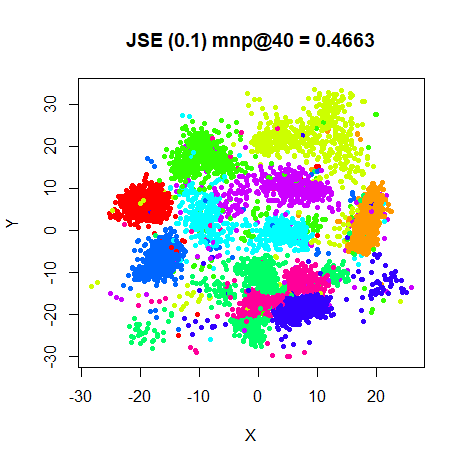

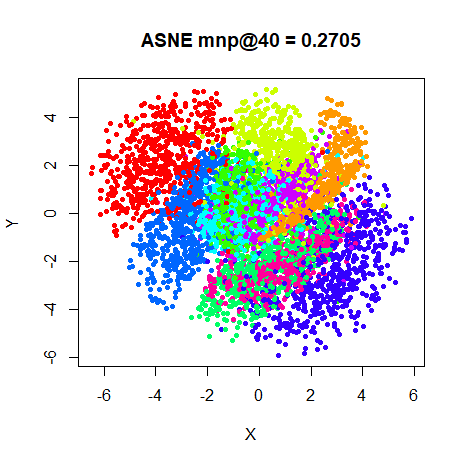

### fashion

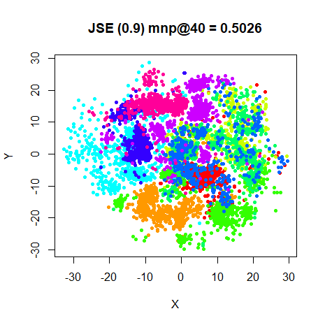

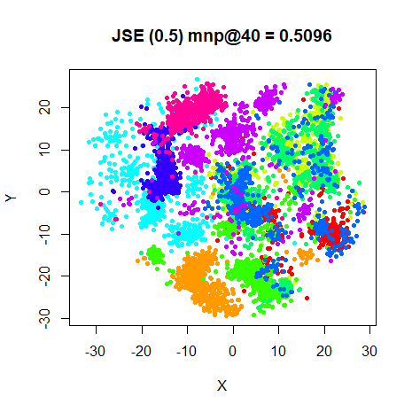

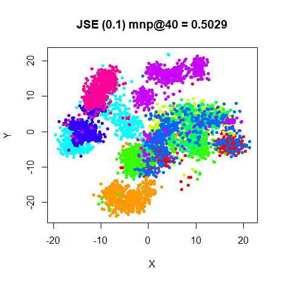

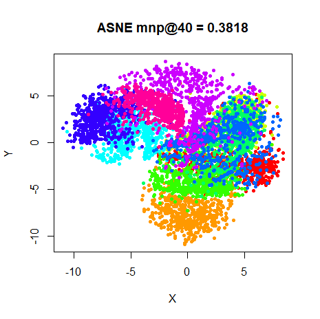

## L-BFGS Optimization

The requirement for the `fashion6k` dataset to avoid divergence by using L-BFGS after a certain number of DBD steps raises the question of whether L-BFGS can just be used for the entire optimization. I repeated some of the above runs where there was a heavier emphasis on the “reverse” KL divergence (NeRV with `lambda = 0.1` and JSE with `kappa = 0.9`) using L-BFGS and allowing up to 2,000 gradient evaluations (`max_gr = 2000`).

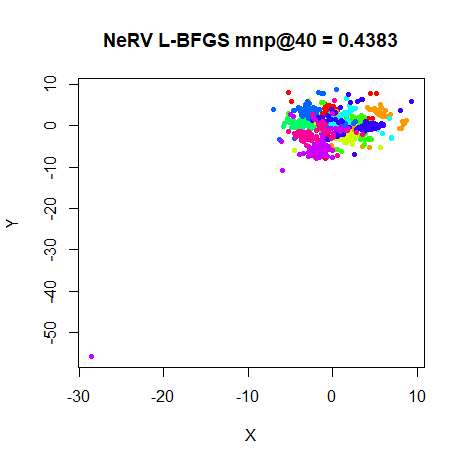

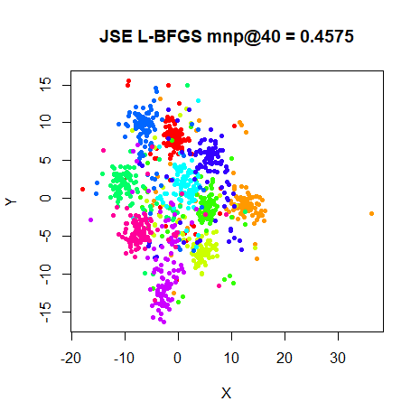

Is this a problem specific to either the implementation of L-BFGS optimization or the definition of JSE and NeRV used in `smallvis`? Possibly. But if you look at the t-SNE embedding or the ‘20NEWS’ dataset using L-BFGS in the [Majorization Minimization](http://proceedings.mlr.press/v38/yang15a.html) paper by Yang, Peltonen and Kaski, Figure 2, top central panel, also shows a similar outlier problem.

## Conclusions

In terms of neighborhood retrieval, NeRV or JSE can outperform t-SNE: JSE is able to do so on every dataset, and NeRV only fails with `mnist6k` and `fashion6k`. Admittedly, those two are the larger, more difficult cases where we would like to see results. But what is also apparent (and what is also noted in the JSE paper) is that JSE provides results which are noticeably different from ASNE over a larger range of its weighting parameter `kappa` than is achieved with NeRV’s `lambda` parameter. When NeRV does outperform t-SNE, it’s always with `lambda = 0.1`. So there may be values much smaller than `lambda = 0.1` (the smallest value checked here) where NeRV can outperform t-SNE for the `mnist6k` and `fashion6k` datasets. For JSE, the optimal value of `kappa` was either `0.1` or `0.5`, except for `iris`, where the optimal value was `0.9`.

However, I’m not sure I visually like the JSE or NeRV results better than t-SNE. They are definitely better than ASNE, but looking at, for example, the `mnist6k` results for JSE with `kappa = 0.1`, while quantitatively, it is superior to the t-SNE results, visually, it’s not as appealing in terms of separating the clusters. Similar arguments can be applied to the `oli` and `s1k` results. But on yet another hand, I think the `fashion6k` results for JSE with `kappa = 0.1` might be a little bit better than the t-SNE results. The JSE paper also notes the less well-clustered nature of the results for the MNIST digits, but claims that this more accurately represents the presence of outlier (badly distored) digits. I’ll admit that I haven’t double-checked this, but I have no reason to disbelieve the authors.

Finally, both NeRV and JSE have a more complicated gradient than t-SNE that results in a slower optimization. Plus, as noted above, they both seem harder to optimize than t-SNE. My current recommendation is to use DBD where possible, but the default learning rate needs to be modified and the more the “reverse” KL divergence is favored (i.e. `kappa` approaching 1 `lambda` approaching 0) the more gentle an optimization is needed, so turn down the `momentum` and `final_momentum` parameters. L-BFGS doesn’t seem like a good alternative, except as a way to refine (if necessary) a short DBD run i.e. 200-500 iterations of DBD, then initialize the L-BFGS optimization with the DBD coordinates.

## Addendum: Normalization Comparison

Update (January 23 2018): Results based on fiddling with different [normalization](https://jlmelville.github.io/smallvis/norm.html) options in SNE suggested that there might be some value in symmetrizing and then re-applying the row-normalization used in ASNE. As JSE and NeRV use the same normalization, it’s worth seeing if this has much effect.

What would be great would be if the optimization problems we see when emphasising the reverse KL divergence in the cost function was ameliorated with this normalization. Alas, this isn’t the case: that `fashion` result still results in divergence. So below are some results under more mild conditions, using `kappa = 0.5` for JSE and `lambda = 0.5` for NeRV. The left-hand images are repeated from the results above. The right-hand images use the new normalization technique (marked as “RSR” in the title of each plot):

### iris

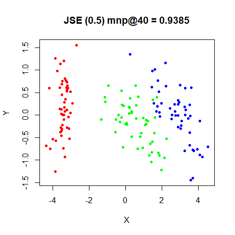

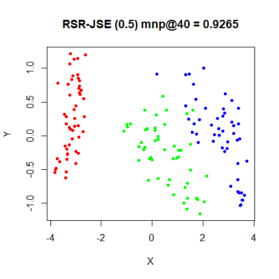

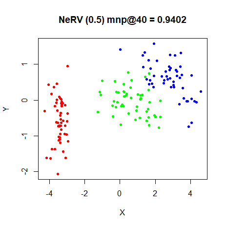

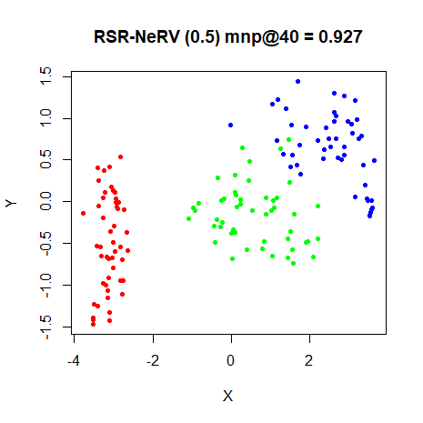

### s1k

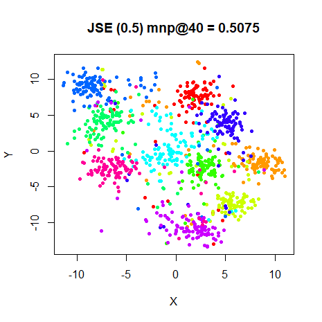

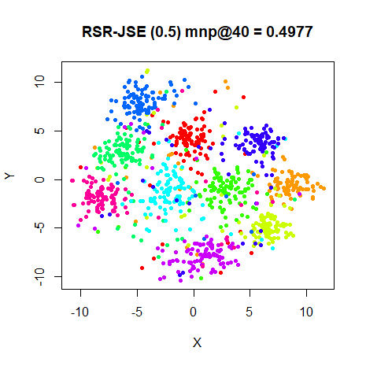

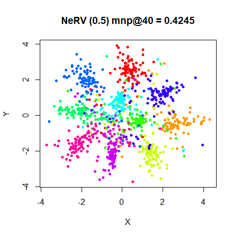

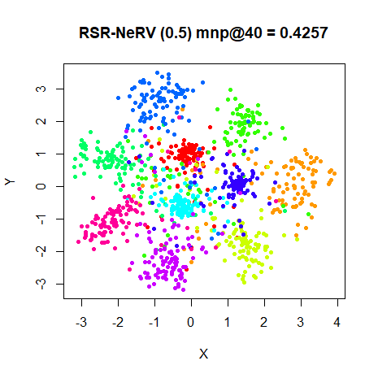

### oli

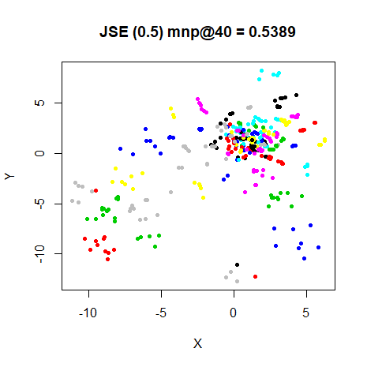

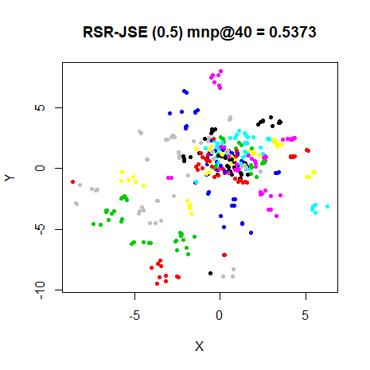

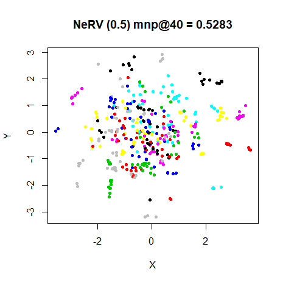

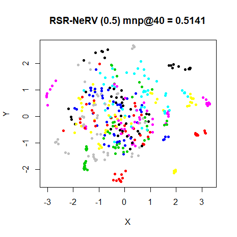

### frey

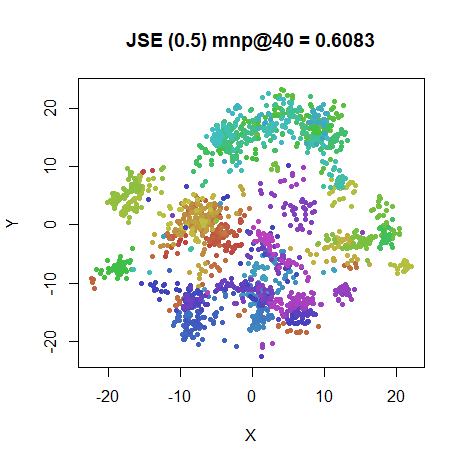

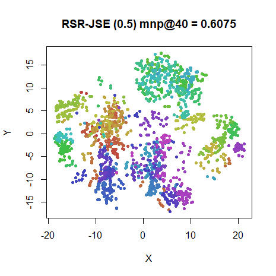

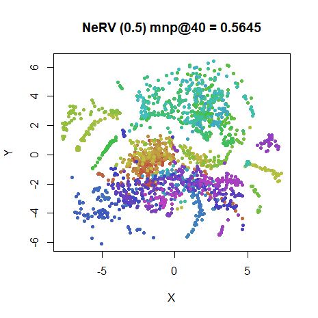

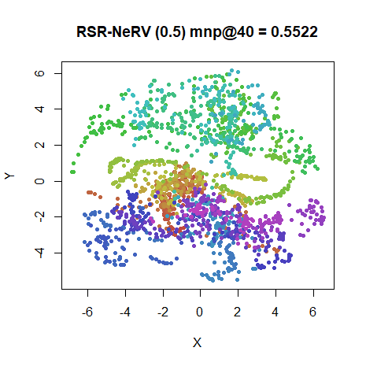

### coil20

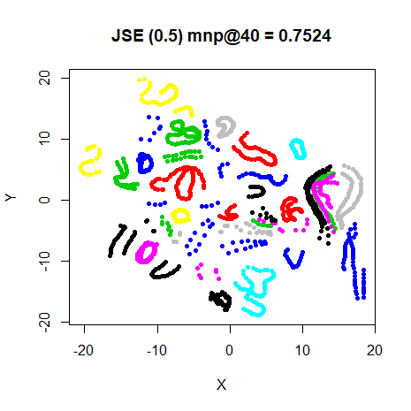

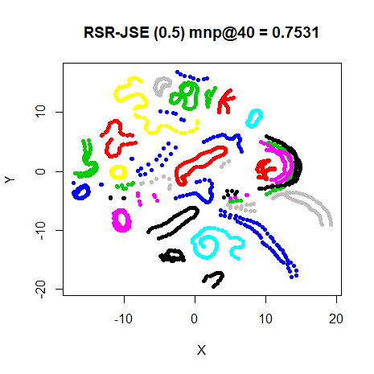

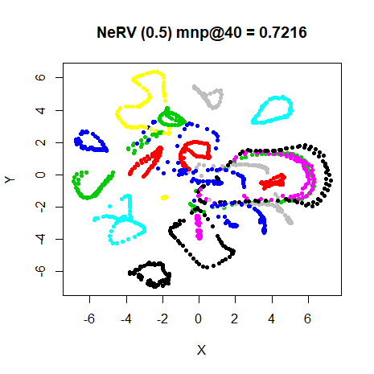

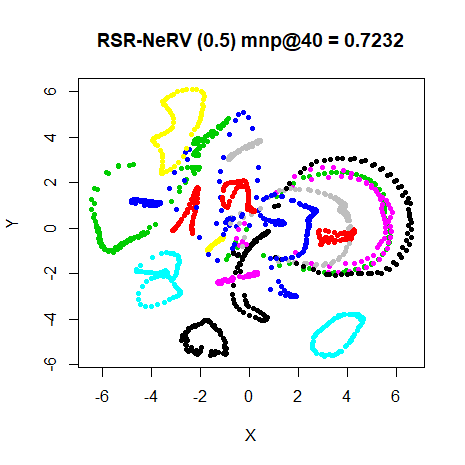

### mnist

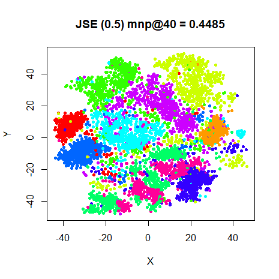

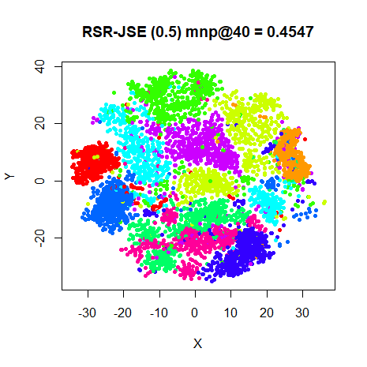

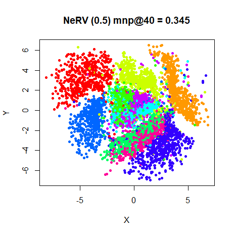

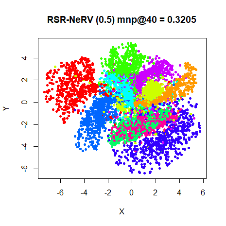

### fashion

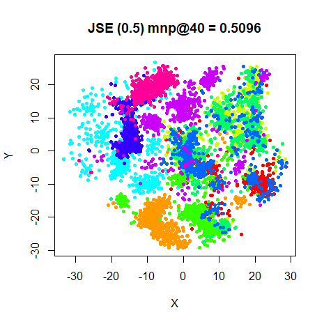

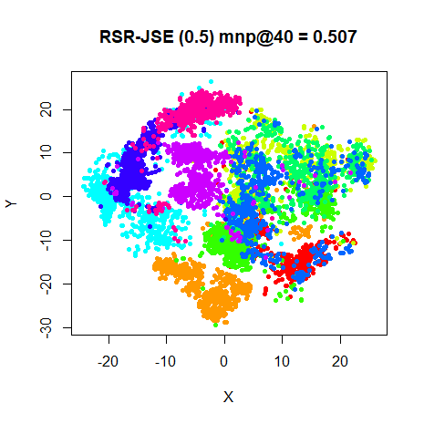

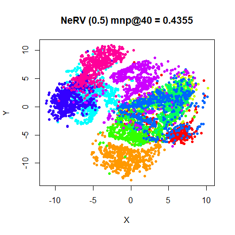

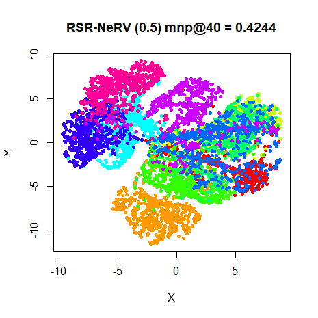

I’d say that these results aren’t that different visually, and don’t offer a significant difference in terms of neighborhood retrieval either. It was worth a shot.

Up: [Documentation Home](https://jlmelville.github.io/smallvis/).